# ggpubr

MG

10 sierpnia 2018

## Pakiet ggpubr()

Wykresy gotowe do publikacji, wykorzystujące możliwości *ggplot2*, jednocześnie ułatwiając ich stosowanie dzięki zastosowaniu funkcji *ggpar()*. Parametry graficzne, które można zmienić z wykorzystaniem funkcji *ggpar()* to:

- tytuł wykresu, oznaczenia osi, opisy legendy
- umiejscowienie legendy i jej wygląd
- kolory
- wartości maksymalne i minimalne osi
- rodzaj transformacji warości osi (np. oś logarytmiczna)
- znaczniki osi
- estetykę/ wygląd wykresu z wykorzystaniem tematów (Themes)
- rotowanie wykresu

### Podstawowy wykres pudełkowy (ang: boxplot)

```r
# if(!require(devtools)) install.packages("ggpubr")
# if(!require(devtools)) install.packages("devtools")
# devtools::install_github("kassambara/ggpubr")

library(ggpubr)

# Podstawowy wykres, wykorzystujacy zaimplementowane w R dane 'ToothGrowth'

data <- ToothGrowth
head(data)
```

```
##    len supp dose
## 1  4.2   VC  0.5
## 2 11.5   VC  0.5
## 3  7.3   VC  0.5
## 4  5.8   VC  0.5
## 5  6.4   VC  0.5
## 6 10.0   VC  0.5
```

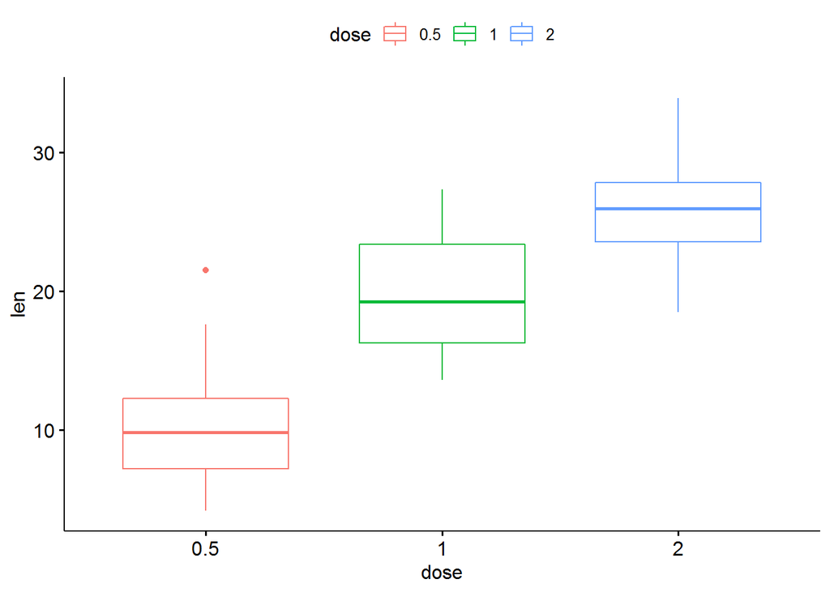

```r
p <- ggboxplot(ToothGrowth, x = "dose", y = "len",
               color = "dose") # wygwnwerowany wykres zapisywany jest jako lista o nazwie p, do której możemy odwoływać się wprowadzając kolejne zmiany w wyglądzie wykresu
p
```

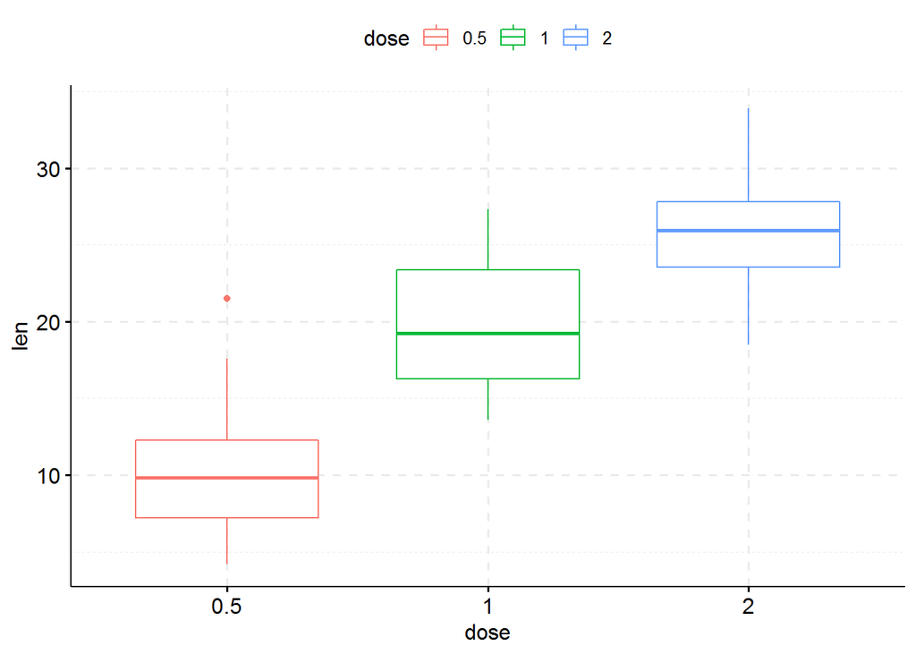

```r
# Add grids
p + grids(linetype = "dashed")
```

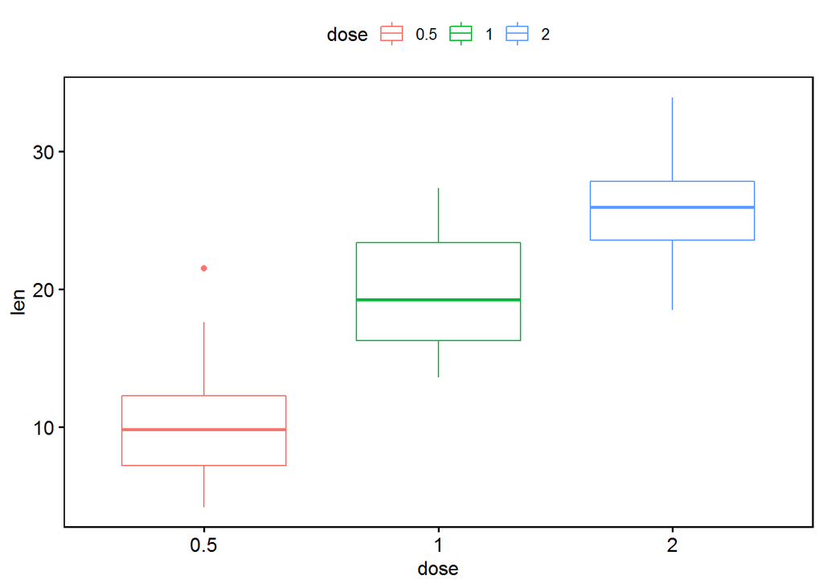

```r
# Add panel border line
p + border("black")
```

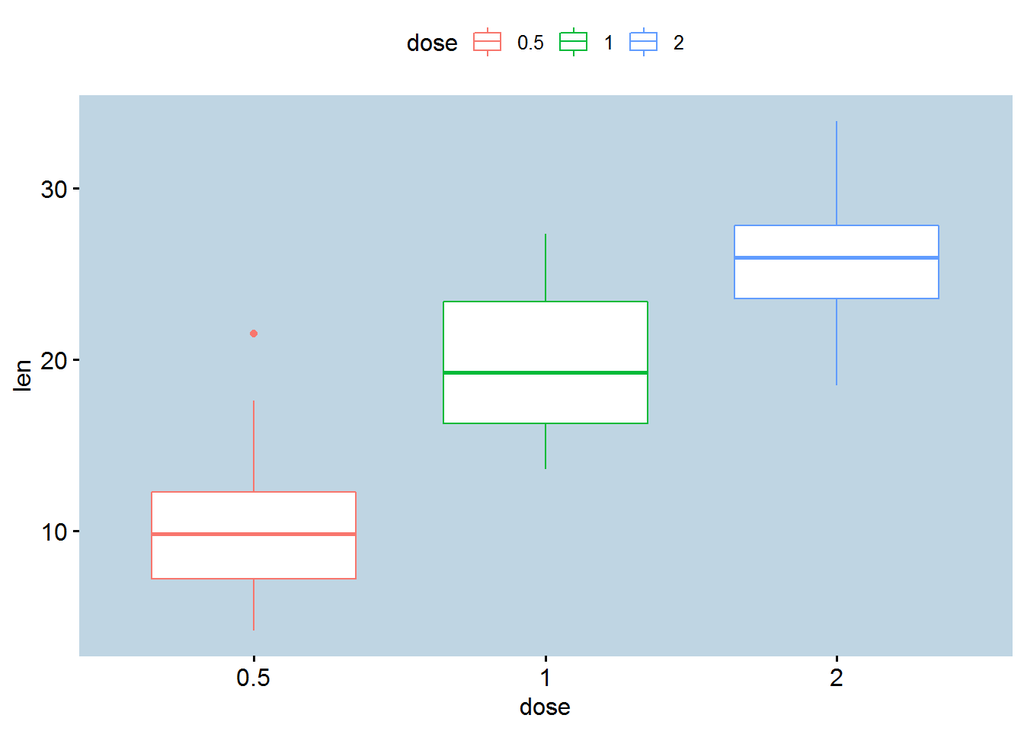

```r
# Change background color
p + bgcolor("#BFD5E3") +
  border("#BFD5E3")
```

### Change titles and axis labels

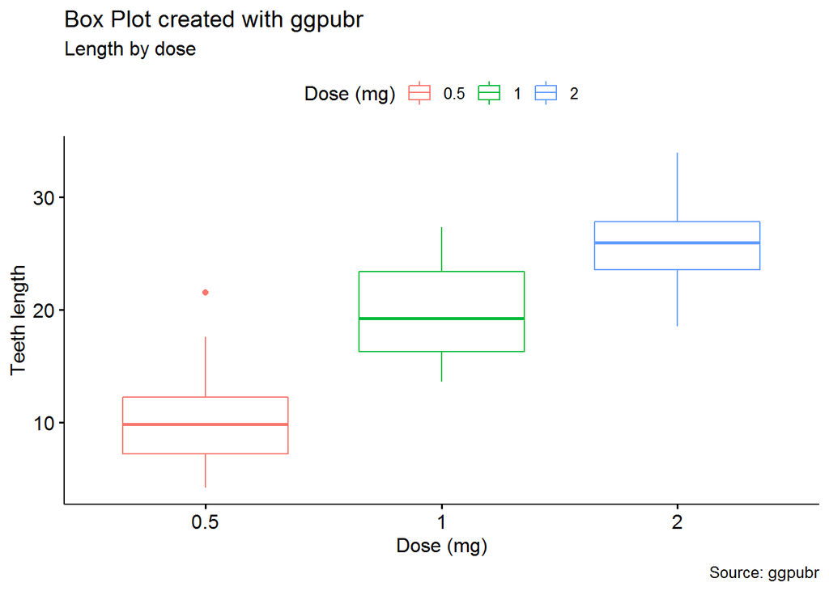

```r
p2 <- ggpar(p,
            title = "Box Plot created with ggpubr",
            subtitle = "Length by dose",
            caption = "Source: ggpubr",
            xlab ="Dose (mg)",
            ylab = "Teeth length",
            legend.title = "Dose (mg)") # Tworzymy 2 listę z parametrami wykresu, aby nie nadpisać pierwszej (p). Teraz możemy odwoływać się również do niej, jako do podstawowego wykresu, który będziemy modyfikować
p2
```

#### zmiana parametrów czcionki

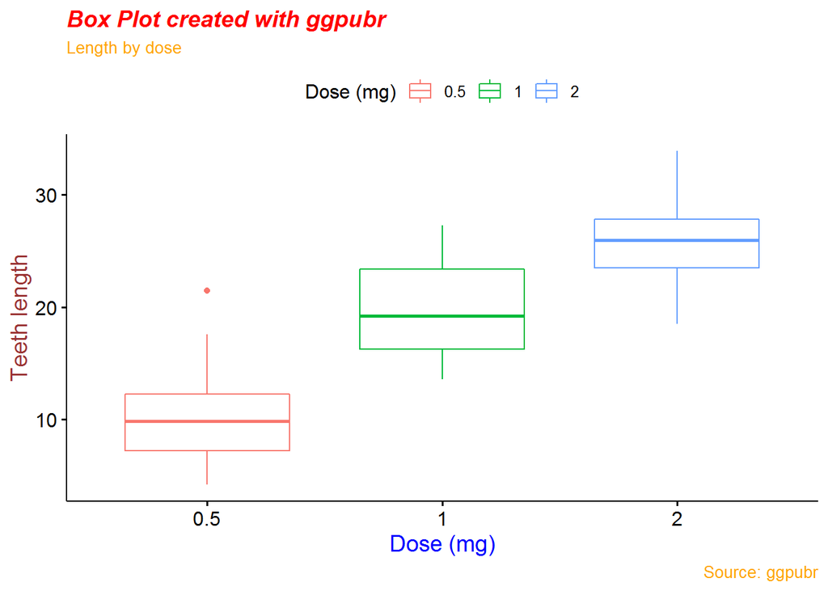

```r
ggpar(p2,
      font.title = c(14, "bold.italic", "red"),
      font.subtitle = c(10,  "orange"),
      font.caption = c(10,  "orange"),
      font.x = c(14,  "blue"),
      font.y = c(14,  "#993333")
      )
```

Alternatywnie z użyciem funkcji *ggplot2* *font()*

```r
# p2 +
# font("title", size = 14, color = "red", face = "bold.italic")+
# font("subtitle", size = 10, color = "orange")+
# font("caption", size = 10, color = "orange")+
# font("xlab", size = 12, color = "blue")+
# font("ylab", size = 12, color = "#993333")
```

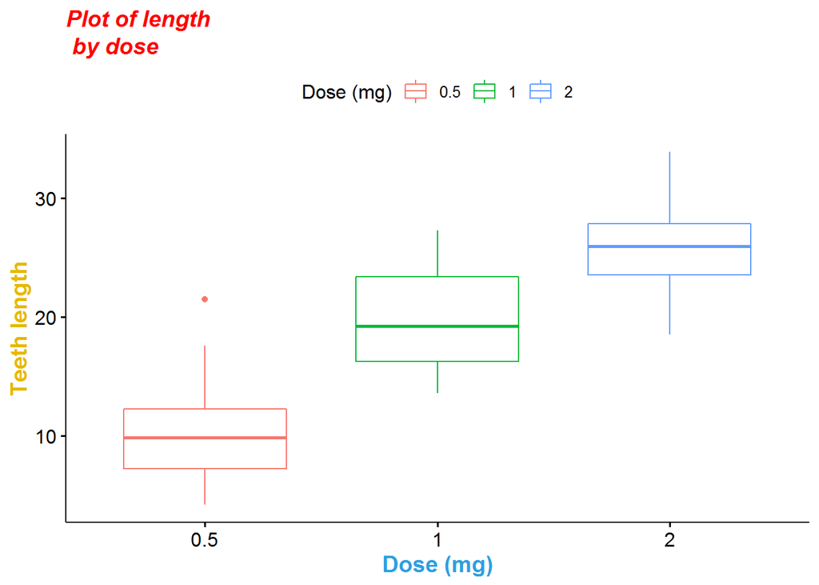

```r
# Change title texts and fonts
# line break: \n
ggpar(p, title = "Plot of length \n by dose",
      xlab ="Dose (mg)", ylab = "Teeth length",
      legend.title = "Dose (mg)",
      font.title = c(14,"bold.italic", "red"),
      font.x = c(14, "bold", "#2E9FDF"),
      font.y = c(14, "bold", "#E7B800"))
```

> - font.title, font.subtitle, font.caption, font.x, font.y are vectors of length 3 indicating respectively the size (e.g.: 14), the style (e.g.: “plain”, “bold”, “italic”, “bold.italic”) and the color (e.g.: “red”) of main title, subtitle, caption, xlab and ylab, respectively. For example font.x = c(14, “bold”, “red”). Use font.x = 14, to change only font size; or use font.x = “bold”, to change only font face.
> - you can use line breaks, to split long title into multiple lines.

### Umiejscowienie i wygląd legendy

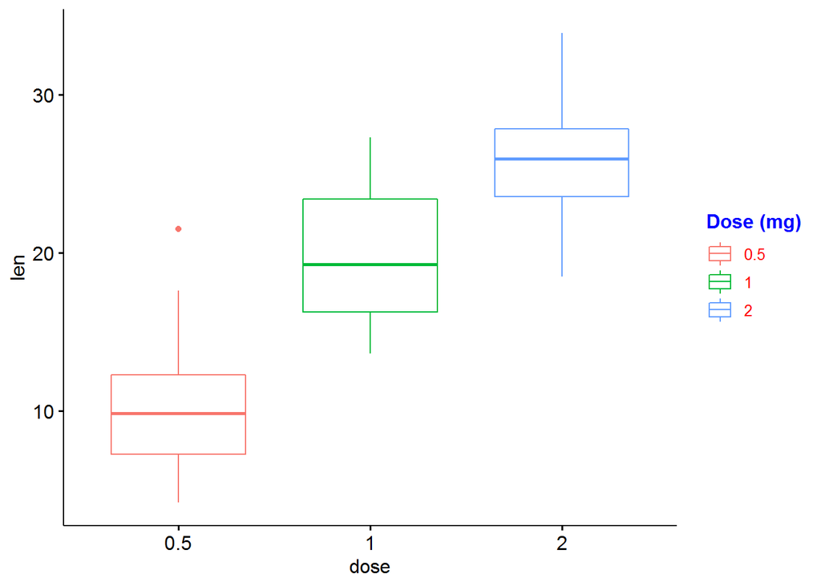

```r
ggpar(p,
      legend = "right", legend.title = "Dose (mg)") +
  font("legend.title", color = "blue", face = "bold")+
  font("legend.text", color = "red")
```

> Note that, the legend argument is a character vector specifying legend position. Allowed values are one of c(“top”, “bottom”, “left”, “right”, “none”). To remove the legend use legend = “none”. Legend position can be also specified using a numeric vector c(x, y). Their values should be between 0 and 1. c(0,0) corresponds to the “bottom left” and c(1,1) corresponds to the “top right” position.

### Zmiana palety kolorów

Argument **palette** funkcji *ggpar()* służy do zmiany palety kolorów stosowanych w wykresach. Dozwolone jest korzystanie z:

- samodzielnie dobranych zestawów kolorów np.: c(“blue”, “red”) lub c(“#00AFBB”, “#E7B800”);
- plaety szarości z użyciem “grey”;
- palet pakietu *brewer* np.: “RdBu”, “Blues”, …; Aby wyświetlic wszystkie możliwości można wpisać w *R: RColorBrewer::display.brewer.all()*.
- oraz palety przygotowane do zastosowań naukowych (ang: scientific journal palettes) z pakietu *ggsci* np.: “npg”, “aaas”, “lancet”, “jco”, “ucscgb”, “uchicago”, “simpsons” i “rickandmorty”.

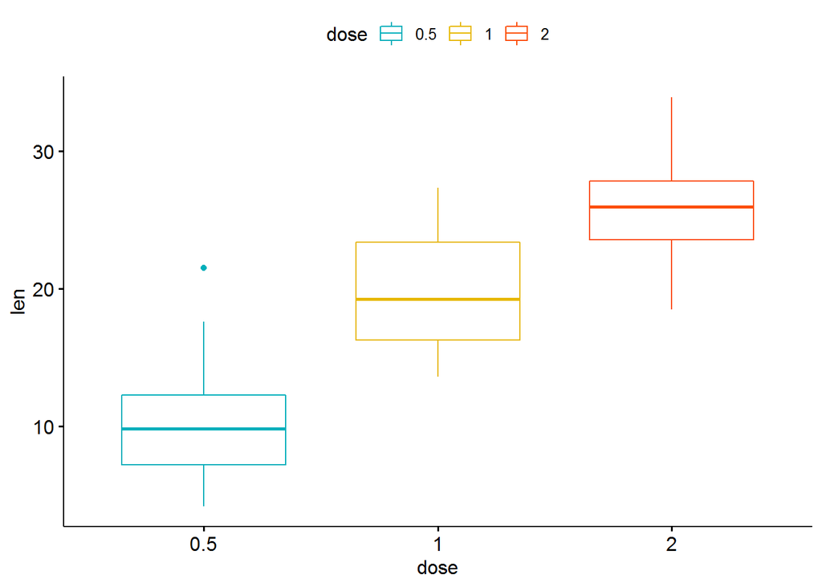

```r
# Use custom color palette
ggpar(p, palette = c("#00AFBB", "#E7B800", "#FC4E07"))
```

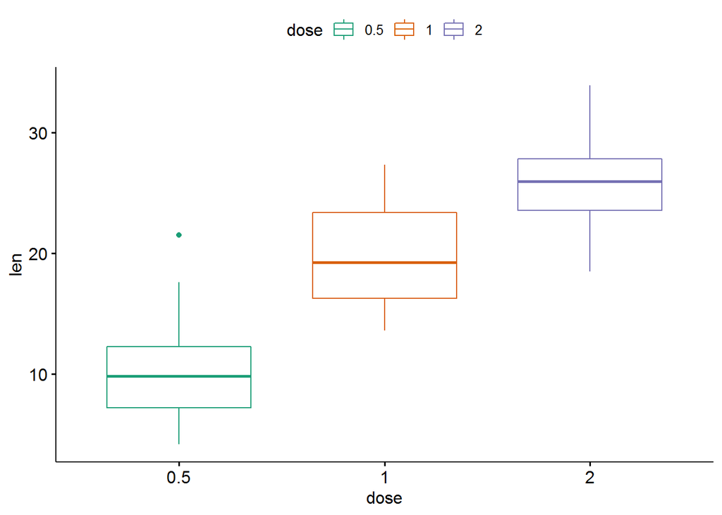

```r
# Use brewer palette.
# Type RColorBrewer::display.brewer.all(), to see possible palettes
ggpar(p, palette = "Dark2" )
```

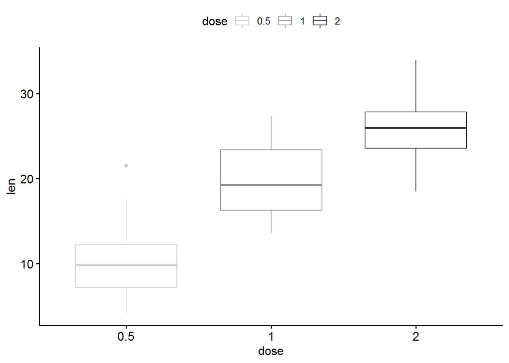

```r
# Use grey palette
ggpar(p, palette = "grey")
```

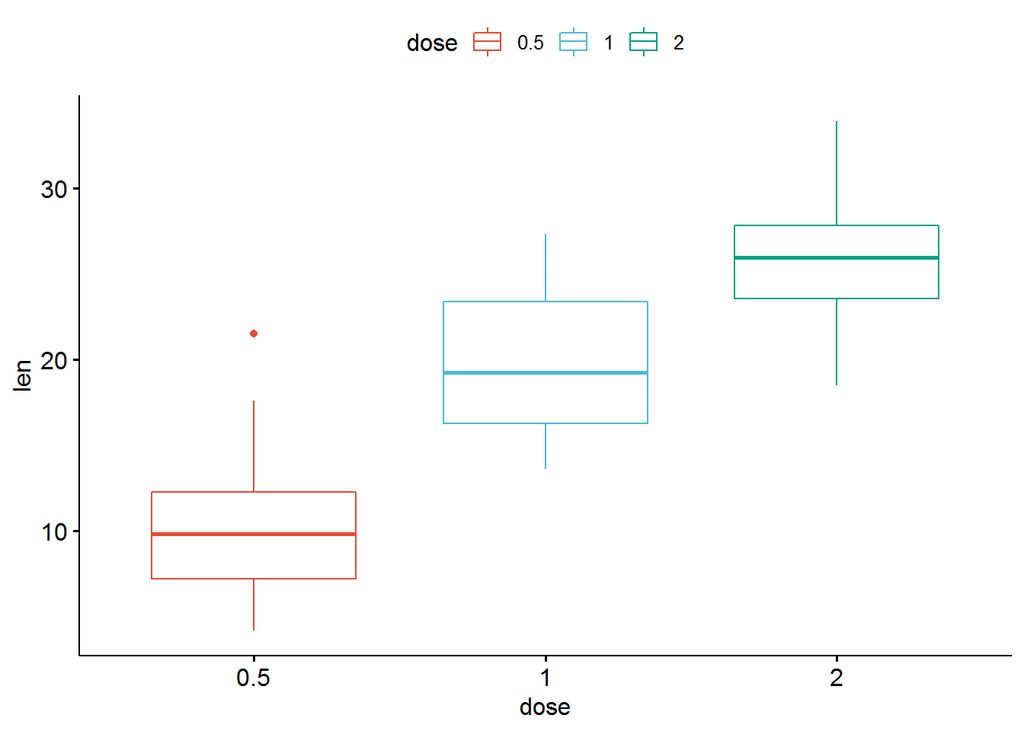

```r
# Use scientific journal palette from ggsci package
# Allowed values: "npg", "aaas", "lancet", "jco",
#   "ucscgb", "uchicago", "simpsons" and "rickandmorty".
ggpar(p, palette = "npg") # nature
```

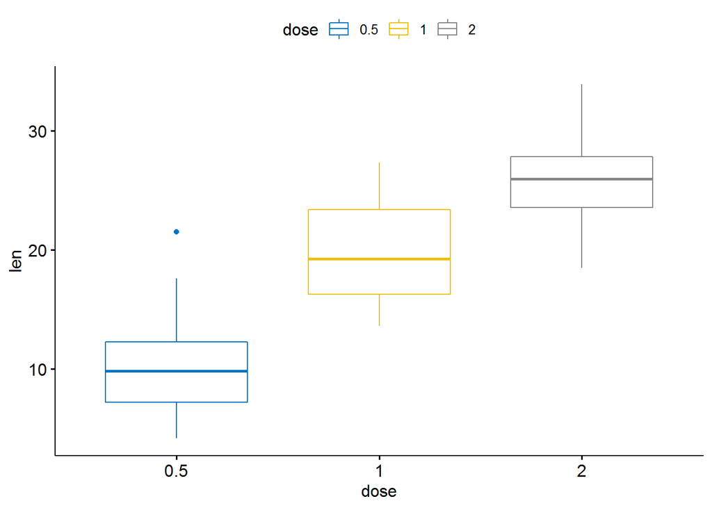

```r
# Alternatywnie można użyć funkcji ggplot2 color_palette() i fill_palette()

# jco color palette
p + color_palette("jco")
```

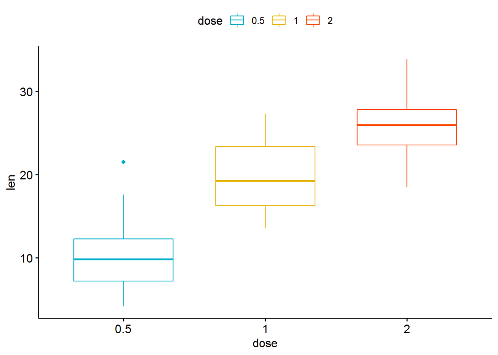

```r
# Custom color
p + color_palette(c("#00AFCB", "#E7B700", "#FC4E08"))
```

### Gradienty kolorów

Do zmiany wypelnień na gradientowe, pakiet *ggpubr* posiada 2 funkcje - *gradient_color()* i *gradient_fill()*. Na przykładzie wykresu punktowego przedsawione zostaną ich możliwości

```r
df <- mtcars
head(df)
```

```
##                    mpg cyl disp  hp drat    wt  qsec vs am gear carb
## Mazda RX4         21.0   6  160 110 3.90 2.620 16.46  0  1    4    4
## Mazda RX4 Wag     21.0   6  160 110 3.90 2.875 17.02  0  1    4    4
## Datsun 710        22.8   4  108  93 3.85 2.320 18.61  1  1    4    1
## Hornet 4 Drive    21.4   6  258 110 3.08 3.215 19.44  1  0    3    1
## Hornet Sportabout 18.7   8  360 175 3.15 3.440 17.02  0  0    3    2
## Valiant           18.1   6  225 105 2.76 3.460 20.22  1  0    3    1
```

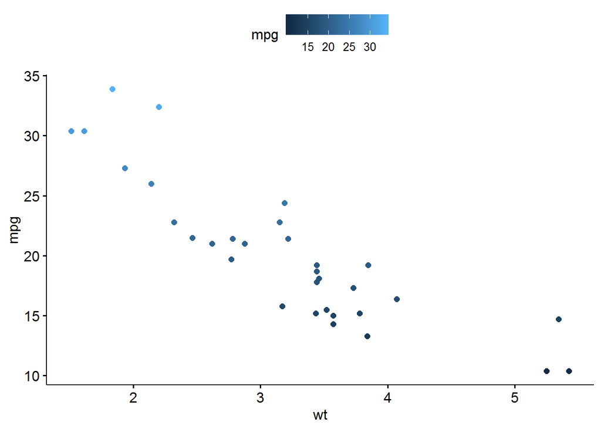

```r
p3 <- ggscatter(mtcars, x = "wt", y = "mpg", color = "mpg",
                size = 2)

p3
```

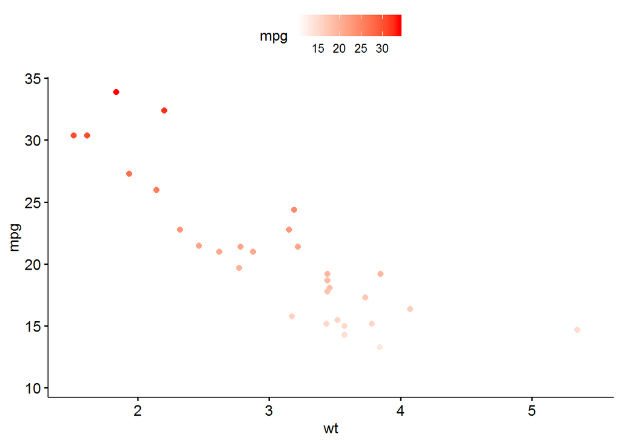

```r
# Use one custom color
p3 + gradient_color("red")
```

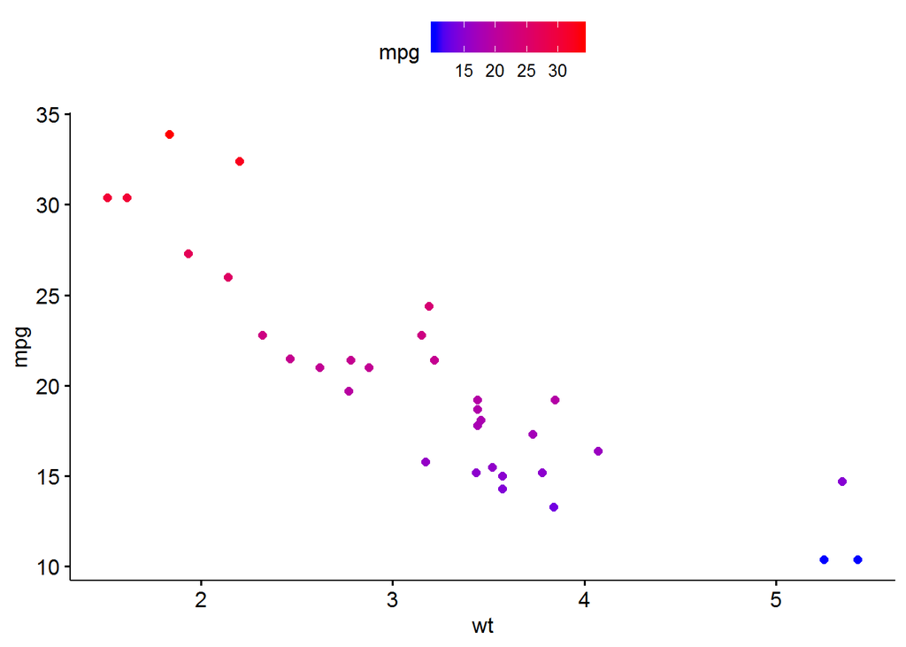

```r
# Two colors
p3 + gradient_color(c("blue",  "red"))
```

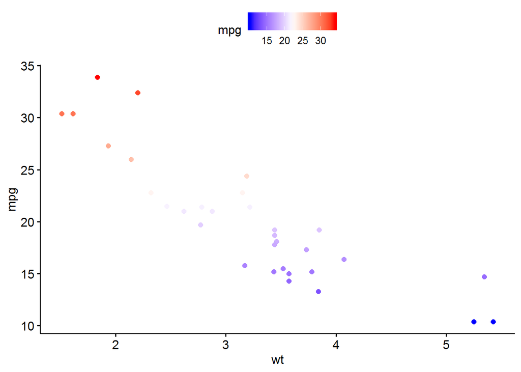

```r
# Three colors
p3 + gradient_color(c("blue", "white", "red"))
```

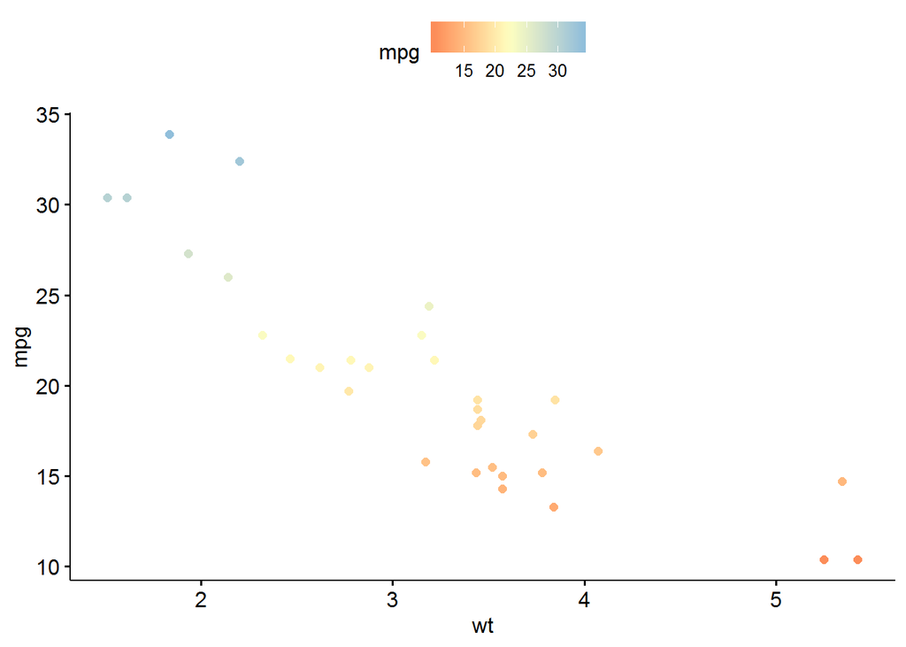

```r
# Use RColorBrewer palette
p3 + gradient_color("RdYlBu")
```

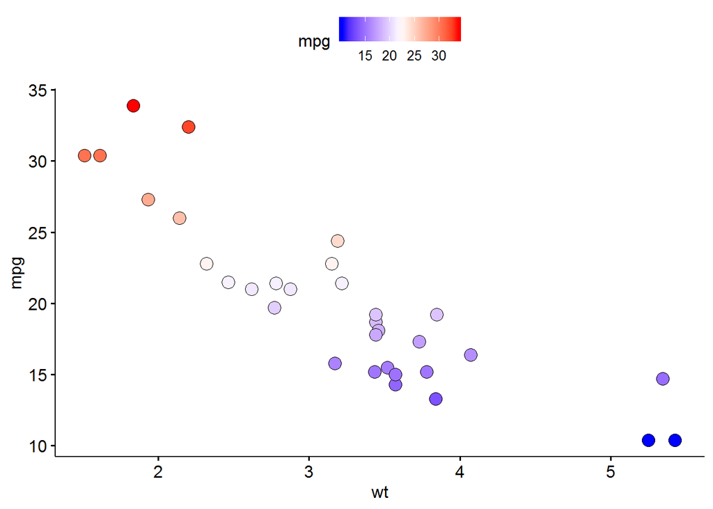

```r
p4 <- ggscatter(mtcars, x = "wt", y = "mpg", fill = "mpg",
                size = 4, shape = 21) # utworzenie wykresu wypełnionego jednolitym kolorem
p4 + gradient_fill(c("blue", "white", "red")) # zmiana koloru na gradient
```

### Zmiana wartości osi i skali

Możliwe jest wykorzystanie następujących argumentów:

- **xlim**, **ylim**: wektor liczbowy o długości 2, określający wartości graniczne osi x i y (odpowiednio, wartość minimum i maksimum) np.: **ylim = c(0, 50)**.
- **xscale**, **yscale**: odpowiednio skala osi x i y. Dozwolona wartość, to jedna z c(“none”, “log2”, “log10”, “sqrt”); np.: **yscale=“log2”**.
- **format.scale**: wartość logiczna. Jeśli **TRUE**, znaczniki osi zostaną przedstawione w postaci potęg, gdy wartości xscale lub yscale = “log2” lub “log10”.

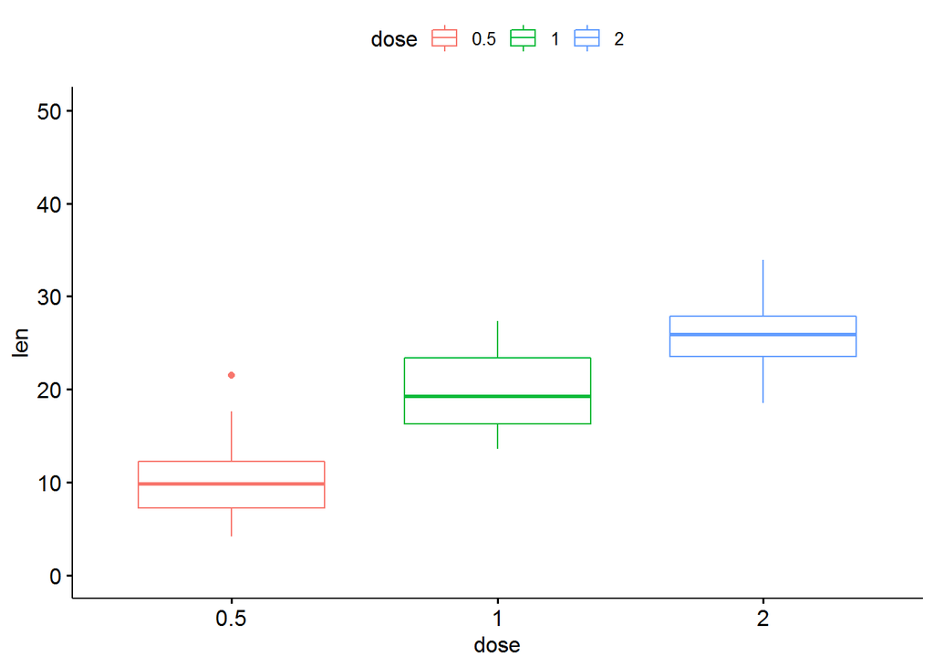

```r
# Change y axis limits
ggpar(p, ylim = c(0, 50))
```

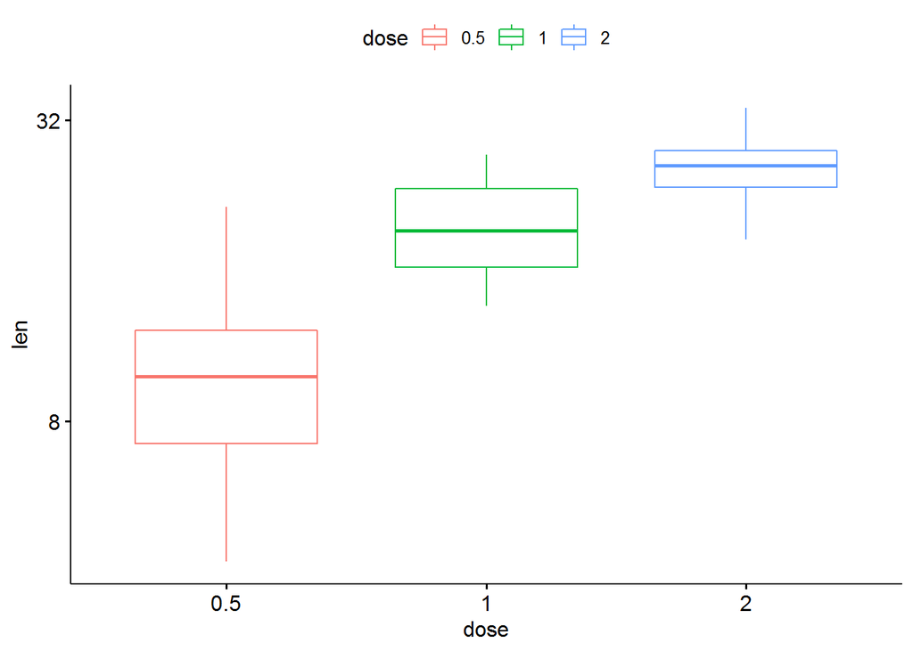

```r
# Change y axis scale to log2
ggpar(p, yscale = "log2")
```

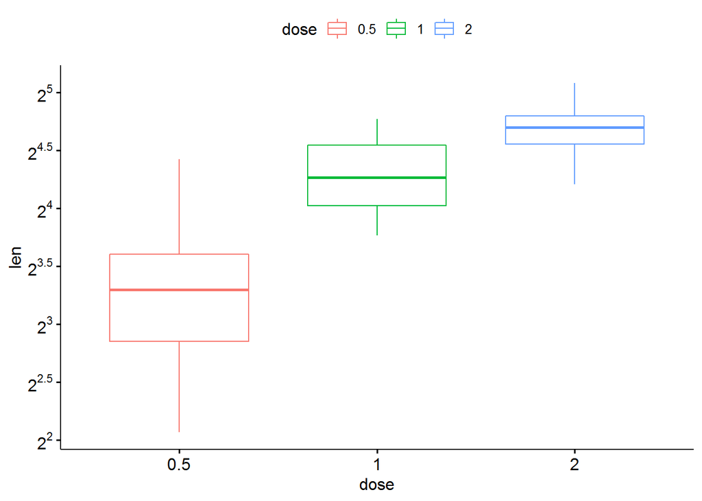

```r
# Format axis scale
ggpar(p, yscale = "log2", format.scale = TRUE)
```

```r
#zapis alternatywny: p + yscale("log2", .format = TRUE)
```

### Dostosowanie opisów osi i znaczników

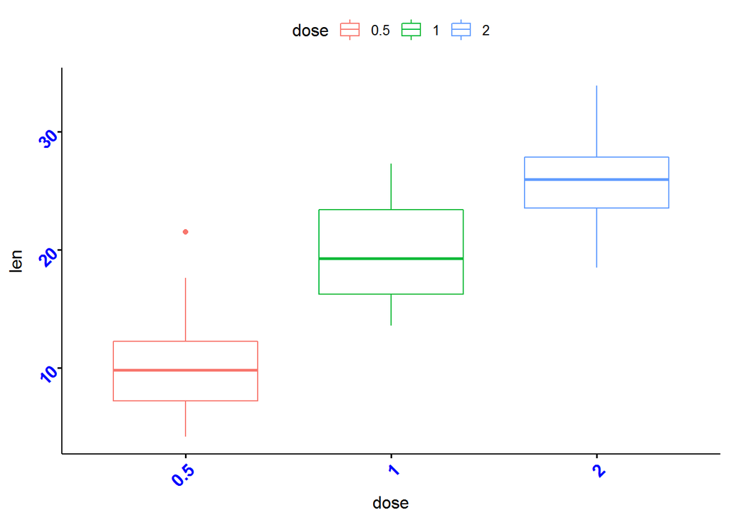

```r
# Change the font of x and y axis texts.
# Rotate x and y texts, angle = 45
p +
  font("xy.text", size = 12, color = "blue", face = "bold") +
  rotate_x_text(45)+
  rotate_y_text(45)
```

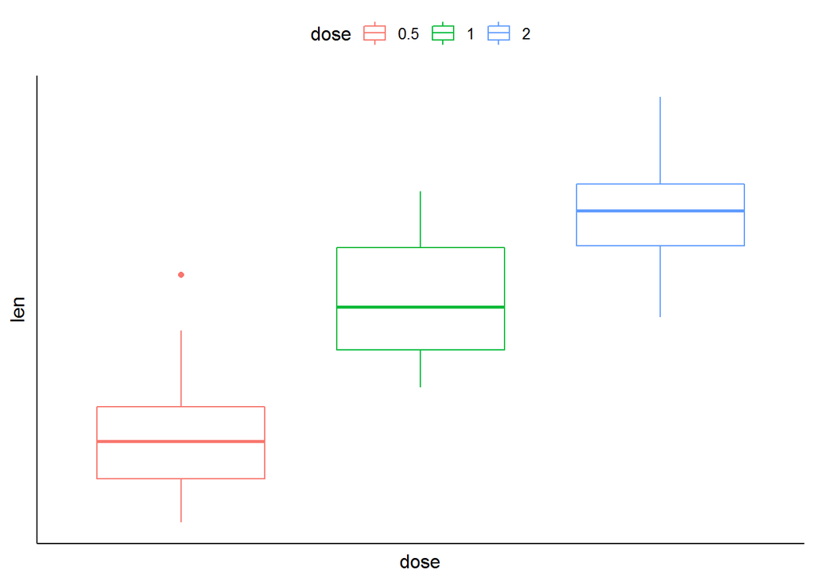

```r
# remove ticks and axis texts
p + rremove("ticks")+
  rremove("axis.text")
```

### Obracanie wykresu

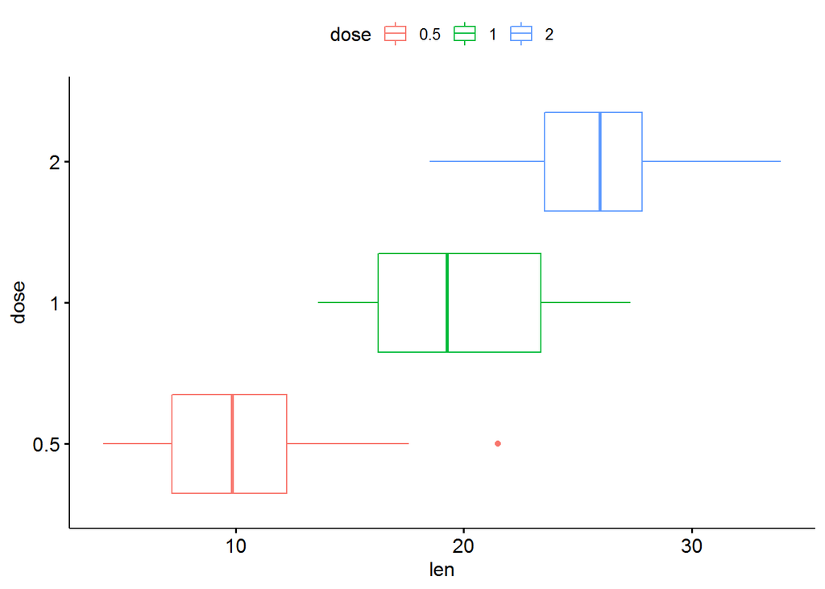

```r
# Horizontal box plot
p + rotate()
```

### Zmiana szablonu wykresu

Z zalożenia wykresy w tym pakiecie tworzone są na podstawie szablonu **theme_pubr()**. Do zmiany szablonu wykorzystywany jest argument **ggtheme**. Dozwolone są oficjalne szablony ggplot2: theme_gray(), theme_bw(), theme_minimal(), theme_classic(), theme_void(), etc. Możliwe jest również wykorzystanie funkcji **“+”** do dodawania stylów.

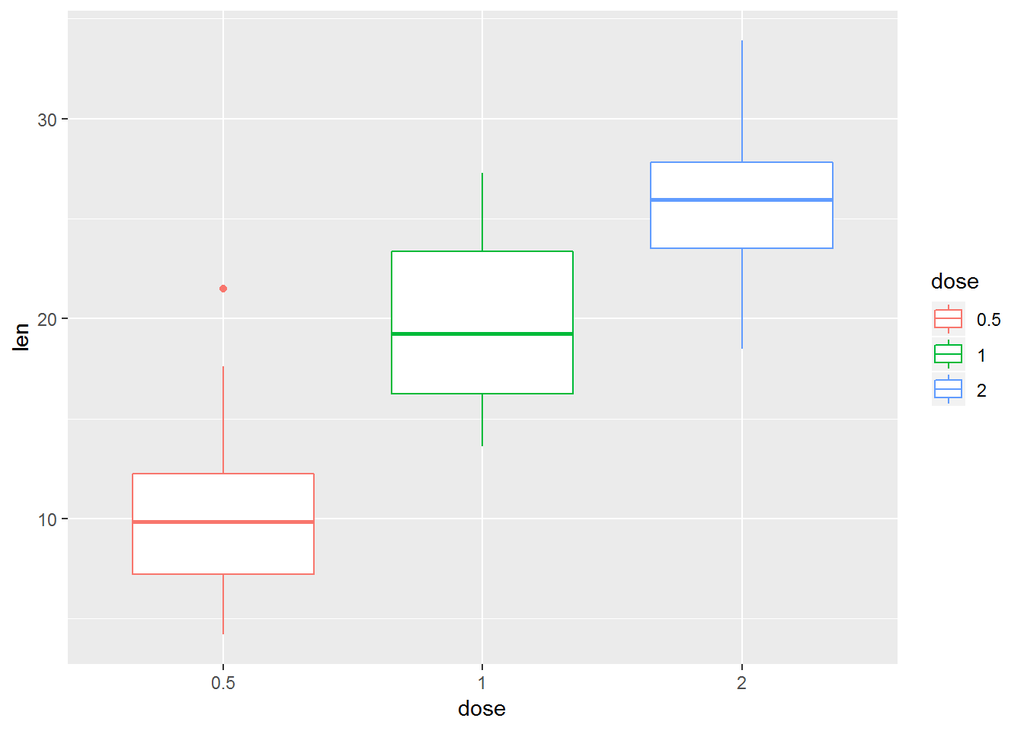

```r
# Gray theme
p + theme_gray()
```

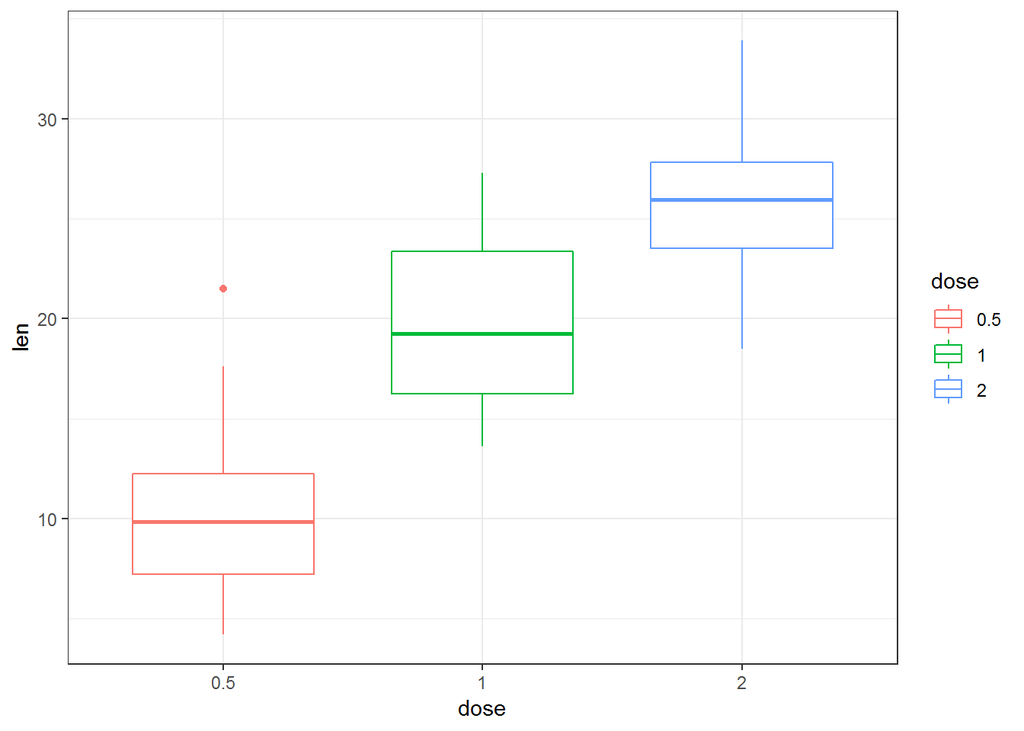

```r
# Black and white theme
p + theme_bw()
```

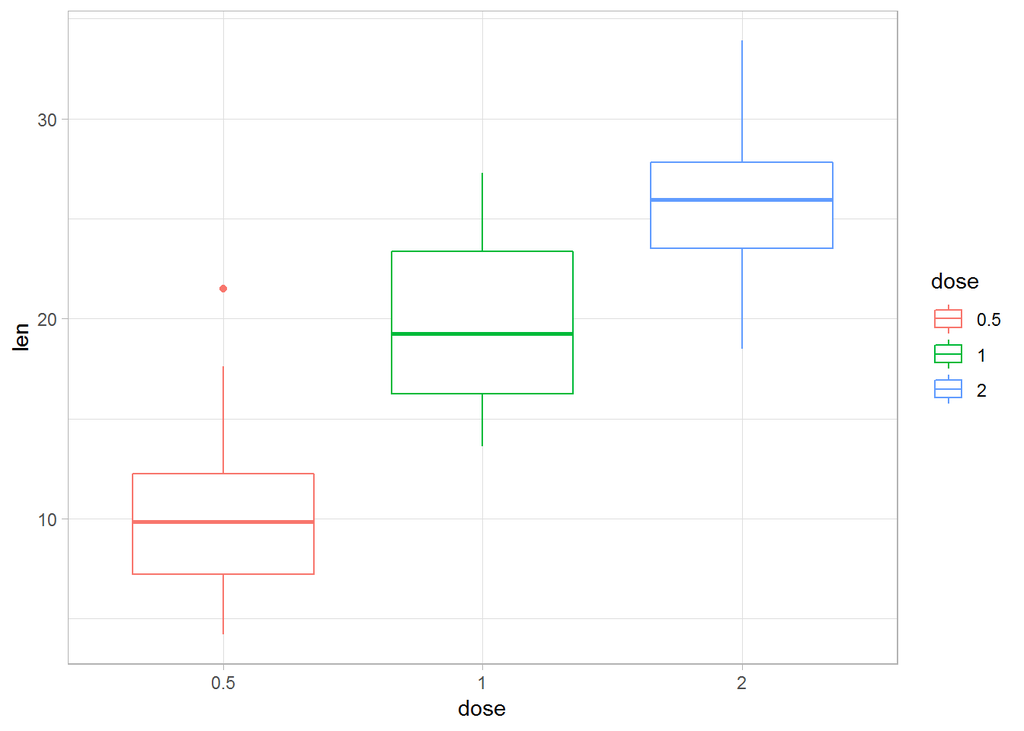

```r
# Theme light
p + theme_light()
```

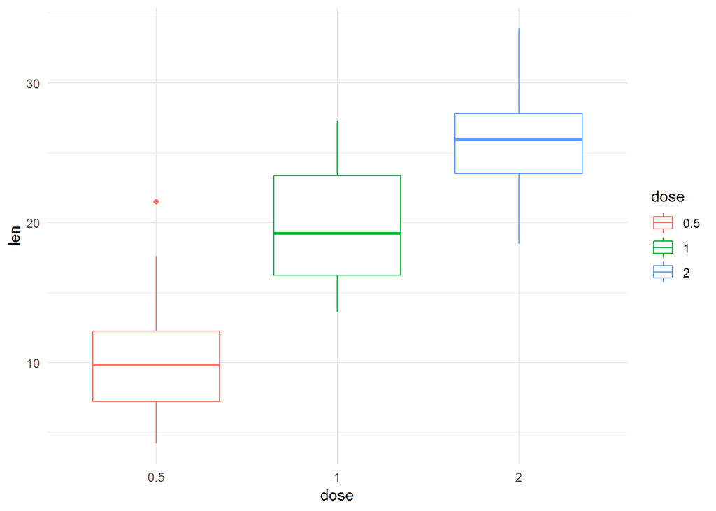

```r
# Minimal theme
p + theme_minimal()
```

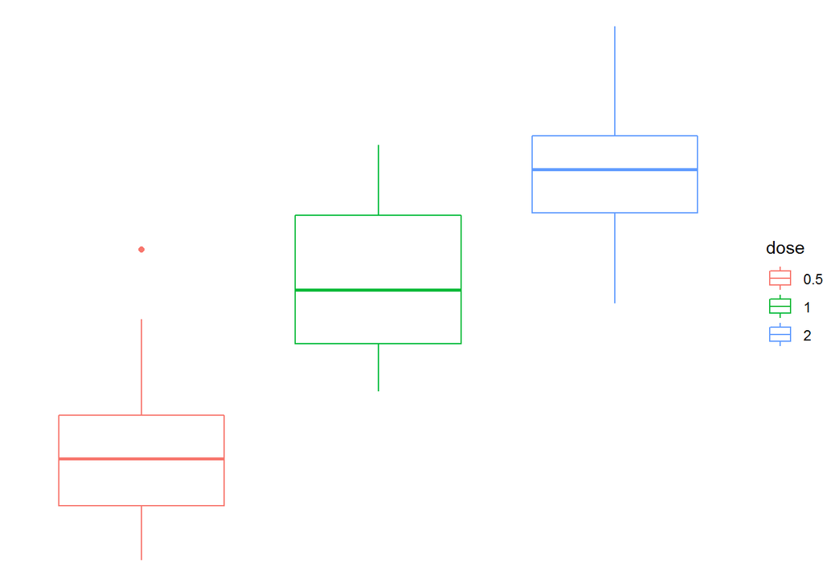

```r
# Empty theme
p + theme_void()
```

### Usuwanie komponentóW wykresu - funkcja **rremove()**

Użycie: rremove(object)

Dozwolone obiekty (objects)

- **“grid”** siatka x i y
- **“x.grid”** siatka po x-ach
- **“y.grid”** siatki po y-ach
- **“axis”** obie osie x i y
- **“x.axis”** oś x
- **“y.axis”** oś y
- **“xlab”**, lub **“x.title”** tytuł osi x
- **“ylab”**, lub **“y.title”** tytuł osi y
- **“xylab”**, **“xy.title”** lub **“axis.title”** tytuły obu osi
- **“x.text”** tekst na osi x (etykiety)
- **“y.text”** tekst na osi y (etykiety)
- **“xy.text”** lub **“axis.text”** tekst na obu osiach
- **“ticks”** znaczniki obu osi
- **“x.ticks”** znaczniki osi x
- **“y.ticks”** znaczniki osi y
- **“legend.title”** tytuł legendy
- **“legend”** całość legendy

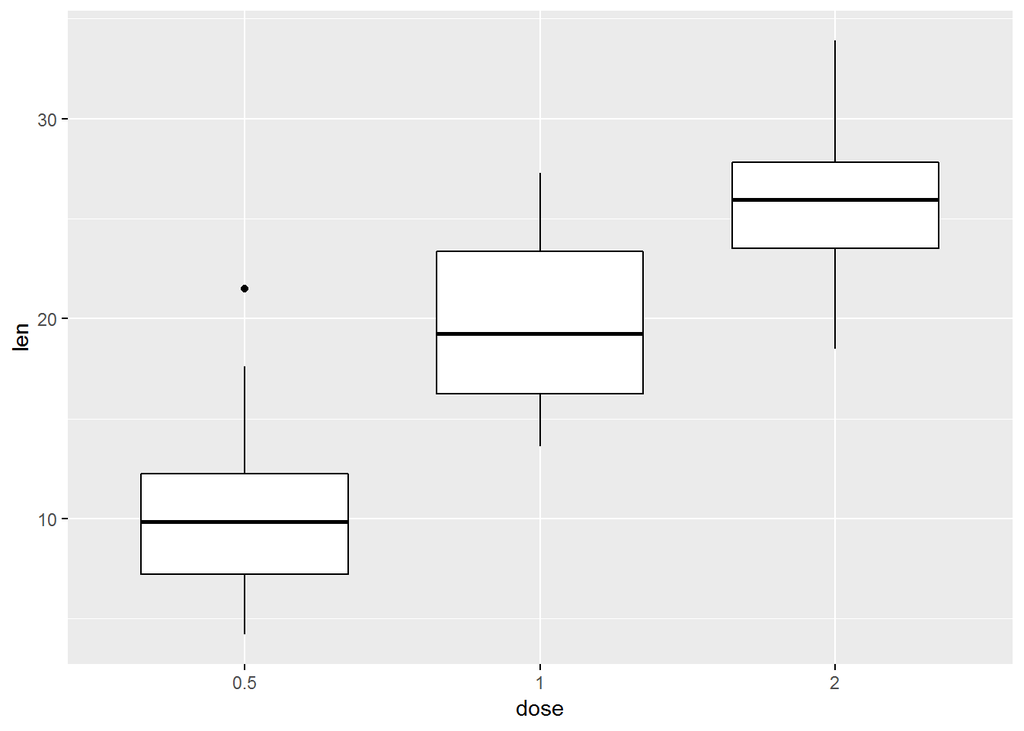

```r
# Basic plot
p <- ggboxplot(ToothGrowth, x = "dose", y = "len",
  ggtheme = theme_gray())
p
```

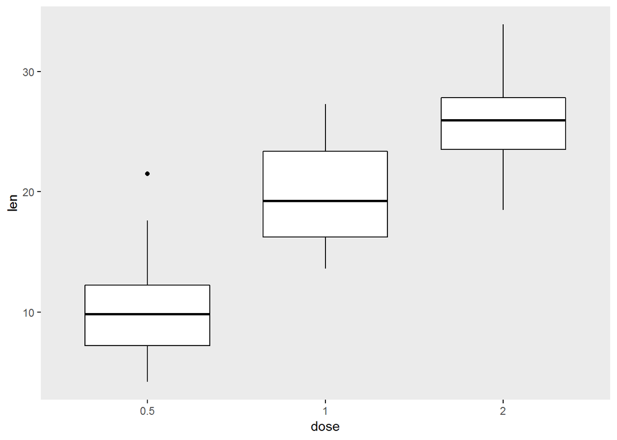

```r
# Remove all grids
p + rremove("grid")
```

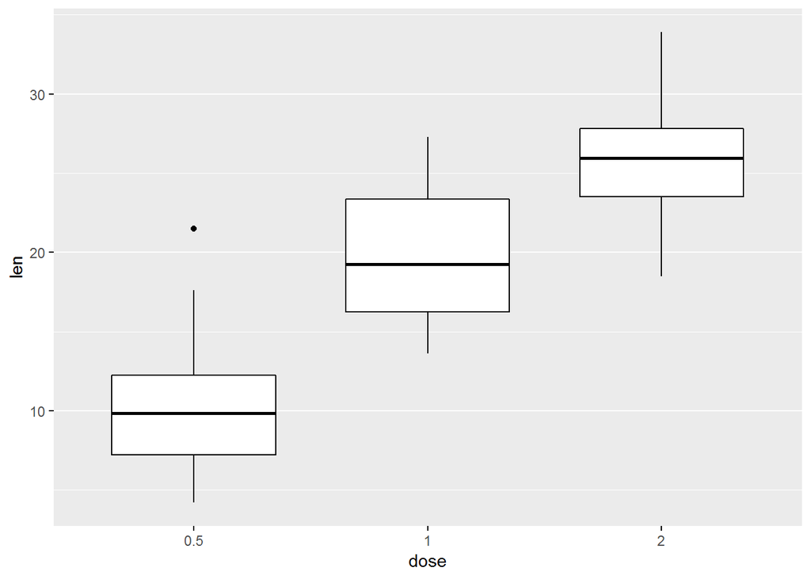

```r
# Remove only x grids
p + rremove("x.grid")
```

## Rozdzielanie wykresów i tworzenie paneli

Wykorzystamy dane *“ToothGrowth”*

```r
data <- ToothGrowth
data$dose <- as.factor(data$dose) # Zmieniamy typ danych w kolumnie dose na czynniki (FACTOR)
head(data)
```

```
##    len supp dose
## 1  4.2   VC  0.5
## 2 11.5   VC  0.5
## 3  7.3   VC  0.5
## 4  5.8   VC  0.5
## 5  6.4   VC  0.5
## 6 10.0   VC  0.5
```

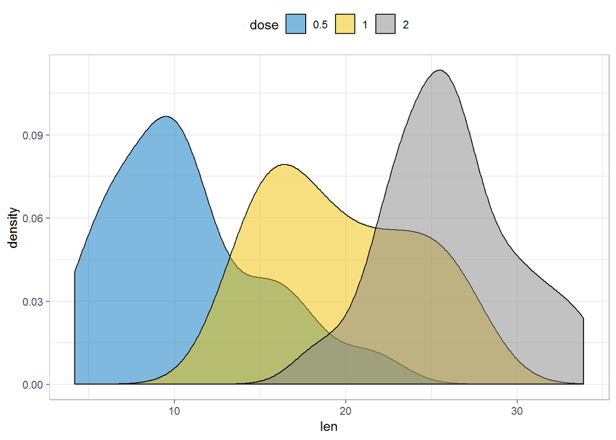

```r
p <- ggdensity(data, x = "len", fill = "dose",
               palette = "jco",
               ggtheme = theme_light(), legend = "top")
p
```

### Przedstawienie danych na niezależnych wykresach po podziale na podstawie jednej z wartości grupujących

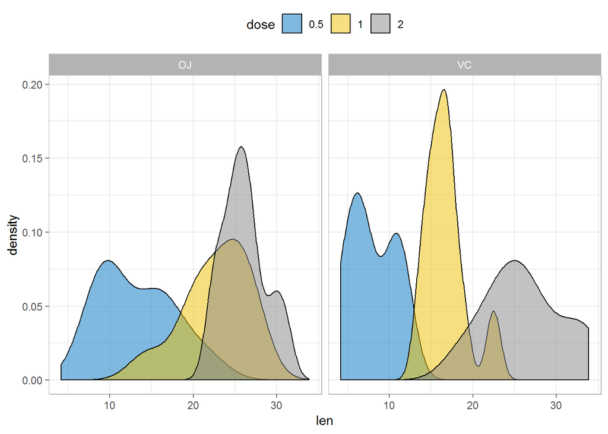

```r
facet(p, facet.by = "supp") # podział na 2 niezależne wykresy na podstawie zmiennej supp
```

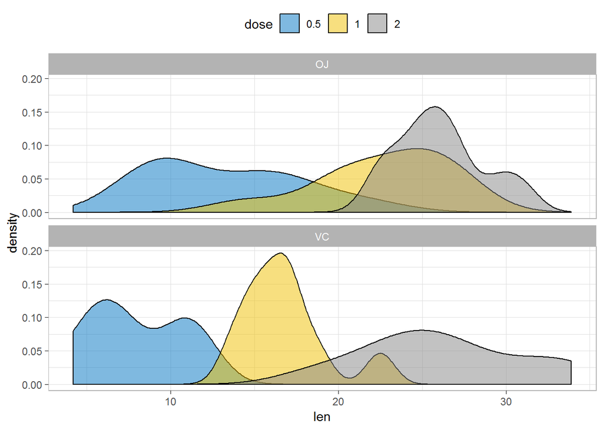

```r
facet(p, facet.by = "supp", ncol = 1) # rozmieszcenie w 1 kolumnie
```

### Przedstawienie danych na niezależnych wykresach po podziale na podstawie dwóch wartości grupujących

The data can be split up by one or two variables that vary on the horizontal and/or vertical direction.

For example in facet.by = c(“supp”, “dose”):

```
“supp”, the first variable, will be displayed in vertical direction
“dose”, the second variable, will be displayed in horizontal direction.
```

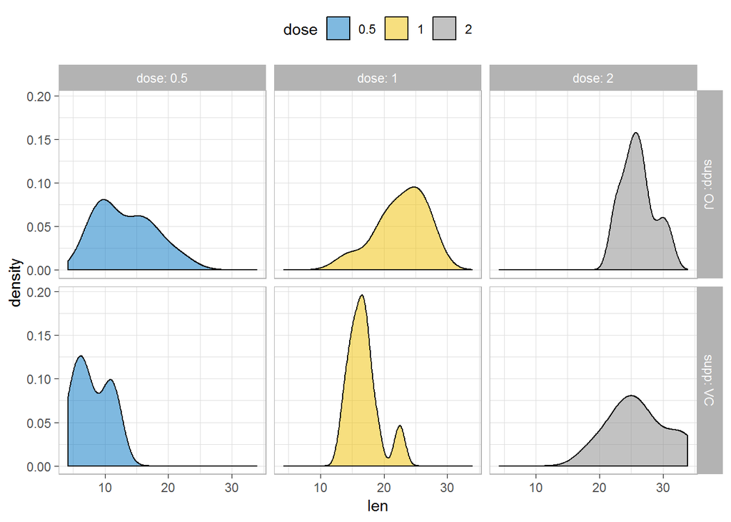

```r
# Divide with "supp" vertical, "dose" horizontal
facet(p, facet.by = c("supp", "dose"),
      short.panel.labs = FALSE)
```

#### Modyfikowanie wygladu paneli

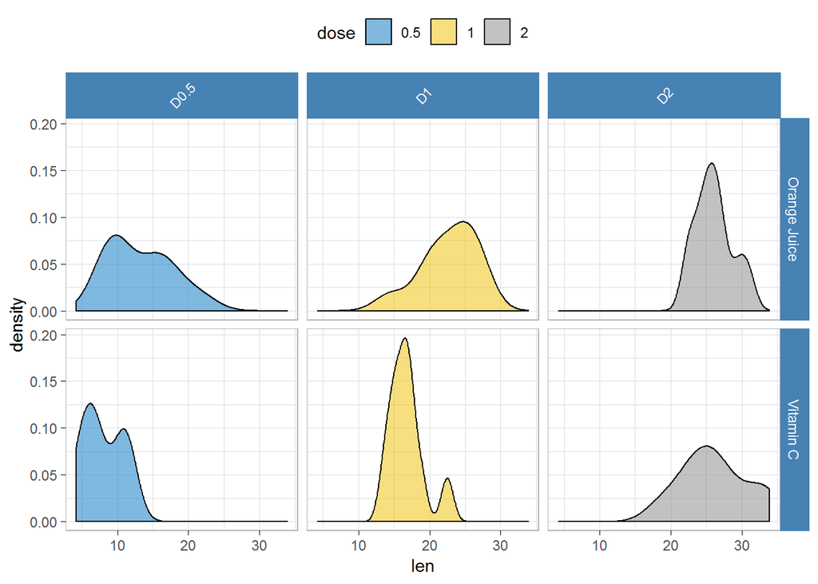

```r
# Podział na "supp" w pionie, "dose" horyzontalnie
facet(p, facet.by = c("supp", "dose"),
       panel.labs = list(
         supp = c("Orange Juice", "Vitamin C"),
         dose = c("D0.5", "D1", "D2") # etykiety paneli po y i x zależne od danych grupujacych "dose"" i "supp""
         ),
       panel.labs.background = list(color = "steelblue", fill = "steelblue", size = 0.5), # kolor paneli (obwódka i wypełnienie) oraz ich rozmiar
       panel.labs.font = list(color = "white"), # kolor czcionki paneli
       panel.labs.font.x = list(angle = 45, color = "white") # parametry czcionek paneli osi x
      )
```